# Introduction to Data Science & Artificial Intelligence

## What is it

> Just as **electricity** transformed almost everything 100 years ago, today I actually have a hard time thinking of an industry that I don’t think **AI** will transform in the next several years.

[figure not shown]

> I’d like to offer an alternative metaphor: machine learning has **become alchemy**.

> There's an anguish in the field ... Many of us feel like we're operating on an **alien technology**.

[figure not shown]

> If you’re arguing against AI, then you’re arguing against **safer cars** that aren’t going to have accidents, and you’re arguing against being able to **better diagnose** people when they’re sick.

[figure not shown]

> I believe AI is one of the more **defining technologies of our time**.

[figure not shown]

## Is data science magic?

**No. It is a statistician who can program.**

[figure not shown]

## What do we do with it

[figure not shown]

- Wayz
- Social media
- Bioinformatics
  - AlphaFold
- Recommender systems
  - Amazon
  - Search engines (Google, Bing)

[figure not shown]

## How do we do it

[figure not shown]

### Tools

- Scripting
  - Python
  - R, Julia
- Data processing/storage
  - SQL
    - Google BigQuery
  - Spark
- Libraries, Packages, Frameworks
  - `Pandas` + `numpy`/`tidyverse`
  - `Scikit-learn`
  - `Tensorflow` / `PyTorch`

## Intro to Pandas

```python
import pandas as pd
import matplotlib.pyplot as plt

plt.style.use("seaborn")
pd.options.display.float_format = '{:.2f}'.format
```

## Youtube Dataset

### The Data

We can take a peek at our data using the `df.head()` function.

```python
df = pd.read_csv('USvideos.csv')
df.head()
```

|  | video_id | trending_date | title | channel_title | category_id | publish_time | tags | views | likes | dislikes | comment_count | thumbnail_link | comments_disabled | ratings_disabled | video_error_or_removed | description |
| --- | --- | --- | --- | --- | --- | --- | --- | --- | --- | --- | --- | --- | --- | --- | --- | --- |
| 0 | 2kyS6SvSYSE | 17.14.11 | WE WANT TO TALK ABOUT OUR MARRIAGE | CaseyNeistat | 22 | 2017-11-13T17:13:01.000Z | SHANtell martin | 748374 | 57527 | 2966 | 15954 | https://i.ytimg.com/vi/2kyS6SvSYSE/default.jpg | False | False | False | SHANTELL'S CHANNEL - https://www.youtube.com/s... |
| 1 | 1ZAPwfrtAFY | 17.14.11 | The Trump Presidency: Last Week Tonight with J... | LastWeekTonight | 24 | 2017-11-13T07:30:00.000Z | last week tonight trump presidency\|"last week ... | 2418783 | 97185 | 6146 | 12703 | https://i.ytimg.com/vi/1ZAPwfrtAFY/default.jpg | False | False | False | One year after the presidential election, John... |
| 2 | 5qpjK5DgCt4 | 17.14.11 | Racist Superman \| Rudy Mancuso, King Bach & Le... | Rudy Mancuso | 23 | 2017-11-12T19:05:24.000Z | racist superman\|"rudy"\|"mancuso"\|"king"\|"bach"... | 3191434 | 146033 | 5339 | 8181 | https://i.ytimg.com/vi/5qpjK5DgCt4/default.jpg | False | False | False | WATCH MY PREVIOUS VIDEO ▶ \n\nSUBSCRIBE ► http... |
| 3 | puqaWrEC7tY | 17.14.11 | Nickelback Lyrics: Real or Fake? | Good Mythical Morning | 24 | 2017-11-13T11:00:04.000Z | rhett and link\|"gmm"\|"good mythical morning"\|"... | 343168 | 10172 | 666 | 2146 | https://i.ytimg.com/vi/puqaWrEC7tY/default.jpg | False | False | False | Today we find out if Link is a Nickelback amat... |
| 4 | d380meD0W0M | 17.14.11 | I Dare You: GOING BALD!? | nigahiga | 24 | 2017-11-12T18:01:41.000Z | ryan\|"higa"\|"higatv"\|"nigahiga"\|"i dare you"\|"... | 2095731 | 132235 | 1989 | 17518 | https://i.ytimg.com/vi/d380meD0W0M/default.jpg | False | False | False | I know it's been a while since we did this sho... |

As we have some time-based data, we should convert it to a datetime object.

```python
# http://strftime.org/
df.trending_date = pd.to_datetime(df.trending_date, format="%y.%d.%m")
df.publish_time = pd.to_datetime(df.publish_time, format="%Y-%m-%dT%H:%M:%S.%fZ")
```

The `df.describe()` method lets us view summary statistics about our data.

```python
df.describe()
```

|  | category_id | views | likes | dislikes | comment_count |
| --- | --- | --- | --- | --- | --- |
| count | 40949.00 | 40949.00 | 40949.00 | 40949.00 | 40949.00 |
| mean | 19.97 | 2360784.64 | 74266.70 | 3711.40 | 8446.80 |
| std | 7.57 | 7394113.76 | 228885.34 | 29029.71 | 37430.49 |
| min | 1.00 | 549.00 | 0.00 | 0.00 | 0.00 |
| 25% | 17.00 | 242329.00 | 5424.00 | 202.00 | 614.00 |
| 50% | 24.00 | 681861.00 | 18091.00 | 631.00 | 1856.00 |
| 75% | 25.00 | 1823157.00 | 55417.00 | 1938.00 | 5755.00 |
| max | 43.00 | 225211923.00 | 5613827.00 | 1674420.00 | 1361580.00 |

### Data Manipulation

Let's add a column for the like percentage of each video. Note how operators can be used directly on columns.

```python
df["like_pct"] = df.likes / (df.likes + df.dislikes)
```

If we only want to view a subset of the data frame, we can use a list of column names as our index.

```python
selected_columns = ["title", "channel_title", "views", "likes", "dislikes", "like_pct", "video_id"]
df[selected_columns].head(10)
```

|  | title | channel_title | views | likes | dislikes | like_pct | video_id |
| --- | --- | --- | --- | --- | --- | --- | --- |
| 0 | WE WANT TO TALK ABOUT OUR MARRIAGE | CaseyNeistat | 748374 | 57527 | 2966 | 0.95 | 2kyS6SvSYSE |
| 1 | The Trump Presidency: Last Week Tonight with J... | LastWeekTonight | 2418783 | 97185 | 6146 | 0.94 | 1ZAPwfrtAFY |
| 2 | Racist Superman \| Rudy Mancuso, King Bach & Le... | Rudy Mancuso | 3191434 | 146033 | 5339 | 0.96 | 5qpjK5DgCt4 |
| 3 | Nickelback Lyrics: Real or Fake? | Good Mythical Morning | 343168 | 10172 | 666 | 0.94 | puqaWrEC7tY |
| 4 | I Dare You: GOING BALD!? | nigahiga | 2095731 | 132235 | 1989 | 0.99 | d380meD0W0M |
| 5 | 2 Weeks with iPhone X | iJustine | 119180 | 9763 | 511 | 0.95 | gHZ1Qz0KiKM |
| 6 | Roy Moore & Jeff Sessions Cold Open - SNL | Saturday Night Live | 2103417 | 15993 | 2445 | 0.87 | 39idVpFF7NQ |
| 7 | 5 Ice Cream Gadgets put to the Test | CrazyRussianHacker | 817732 | 23663 | 778 | 0.97 | nc99ccSXST0 |
| 8 | The Greatest Showman \| Official Trailer 2 [HD]... | 20th Century Fox | 826059 | 3543 | 119 | 0.97 | jr9QtXwC9vc |
| 9 | Why the rise of the robots won’t mean the end ... | Vox | 256426 | 12654 | 1363 | 0.90 | TUmyygCMMGA |

Let's take a look at the most viewed videos. We can do this with the `df.sort_values()` method.

```python
df[selected_columns].sort_values("views", ascending=False).head()
```

|  | title | channel_title | views | likes | dislikes | like_pct | video_id |
| --- | --- | --- | --- | --- | --- | --- | --- |
| 38547 | Childish Gambino - This Is America (Official V... | ChildishGambinoVEVO | 225211923 | 5023450 | 343541 | 0.94 | VYOjWnS4cMY |
| 38345 | Childish Gambino - This Is America (Official V... | ChildishGambinoVEVO | 220490543 | 4962403 | 338105 | 0.94 | VYOjWnS4cMY |
| 38146 | Childish Gambino - This Is America (Official V... | ChildishGambinoVEVO | 217750076 | 4934188 | 335462 | 0.94 | VYOjWnS4cMY |
| 37935 | Childish Gambino - This Is America (Official V... | ChildishGambinoVEVO | 210338856 | 4836448 | 326902 | 0.94 | VYOjWnS4cMY |
| 37730 | Childish Gambino - This Is America (Official V... | ChildishGambinoVEVO | 205643016 | 4776680 | 321493 | 0.94 | VYOjWnS4cMY |

What does this tell us about our data? Is it wrong? Duplicated?

### A Closer Look at Gambino's Music Video

We can filter our data to view only this video. the `df.shape` attribute tells us the size of our data frame - in this case, 25 rows by 17 columns.

```python
gambino_df = df[df.video_id == "VYOjWnS4cMY"]
print(gambino.shape)
gambino_df.head(3)
```

```
(25, 17)
```

|  | video_id | trending_date | title | channel_title | category_id | publish_time | tags | views | likes | dislikes | comment_count | thumbnail_link | comments_disabled | ratings_disabled | video_error_or_removed | description | like_pct |
| --- | --- | --- | --- | --- | --- | --- | --- | --- | --- | --- | --- | --- | --- | --- | --- | --- | --- |
| 33351 | VYOjWnS4cMY | 18.08.05 | Childish Gambino - This Is America (Official V... | ChildishGambinoVEVO | 10 | 2018-05-06T04:00:07.000Z | Childish Gambino\|"Rap"\|"This Is America"\|"mcDJ... | 31648454 | 1405355 | 51547 | 149473 | https://i.ytimg.com/vi/VYOjWnS4cMY/default.jpg | False | False | False | “This is America” by Childish Gambino http://s... | 0.96 |
| 33557 | VYOjWnS4cMY | 18.09.05 | Childish Gambino - This Is America (Official V... | ChildishGambinoVEVO | 10 | 2018-05-06T04:00:07.000Z | Childish Gambino\|"Rap"\|"This Is America"\|"mcDJ... | 47169016 | 1841540 | 79717 | 194822 | https://i.ytimg.com/vi/VYOjWnS4cMY/default.jpg | False | False | False | “This is America” by Childish Gambino http://s... | 0.96 |
| 33772 | VYOjWnS4cMY | 18.10.05 | Childish Gambino - This Is America (Official V... | ChildishGambinoVEVO | 10 | 2018-05-06T04:00:07.000Z | Childish Gambino\|"Rap"\|"This Is America"\|"mcDJ... | 60776509 | 2183732 | 104377 | 232723 | https://i.ytimg.com/vi/VYOjWnS4cMY/default.jpg | False | False | False | “This is America” by Childish Gambino http://s... | 0.95 |

It's very easy to graph with `pandas`. Simply calling `df.plot("x", "y")` will work.

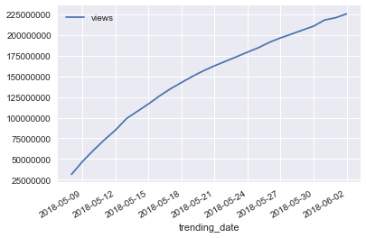

```python
gambino.plot("trending_date", "views")
plt.gca().get_yaxis().get_major_formatter().set_scientific(False) # hide scientific notation on y-axis
plt.show() # renders plot to screen - like pygame.display.update()
```

### Most Trending Videos

There are lots of helpful methods we can apply to the columns of a data frame as well. Here, we can count the number of instances each video appears in our data.

```python
most_trending = df.title.value_counts()
most_trending.head()
```

```
WE MADE OUR MOM CRY...HER DREAM CAME TRUE!              30
The ULTIMATE $30,000 Gaming PC Setup                    29
Why I'm So Scared (being myself and crying too much)    29
Charlie Puth - BOY [Official Audio]                     29
Sam Smith - Pray (Official Video) ft. Logic             29
Name: title, dtype: int64
```

But that's not a data frame! That's a *series* - what Pandas uses as columns. We can also convert it back to a data frame:

```python
most_trending = most_trending.to_frame()
most_trending.head()
```

|  | title |
| --- | --- |
| WE MADE OUR MOM CRY...HER DREAM CAME TRUE! | 30 |
| The ULTIMATE $30,000 Gaming PC Setup | 29 |
| Why I'm So Scared (being myself and crying too much) | 29 |
| Charlie Puth - BOY [Official Audio] | 29 |
| Sam Smith - Pray (Official Video) ft. Logic | 29 |

### Grouping

Sometimes, we don't want to look at each row individually, but instead groups of data (like by youtube channel). For this we can use `df.groupby()`.

```python
trending_channels = df.groupby("channel_title").video_id.size()
trending_channels.head()
```

```
channel_title
12 News                    2
1MILLION Dance Studio     33
1theK (원더케이)              19
20th Century Fox         135
2CELLOS                    2
Name: video_id, dtype: int64
```

```python
trending_channels = trending_channels.nlargest(10).to_frame()
trending_channels
```

| channel_title | video_id |
| --- | --- |
| ESPN | 203 |
| The Tonight Show Starring Jimmy Fallon | 197 |
| Netflix | 193 |
| TheEllenShow | 193 |
| Vox | 193 |
| The Late Show with Stephen Colbert | 187 |
| Jimmy Kimmel Live | 186 |
| Late Night with Seth Meyers | 183 |
| Screen Junkies | 182 |
| NBA | 181 |

`pandas` has also recently introduced another helpful way to plot your data, using `df.style`.

```python
trending_channels.style.bar()
```

| channel_title | video_id |
| --- | --- |
| ESPN | 203 |
| The Tonight Show Starring Jimmy Fallon | 197 |
| Netflix | 193 |
| TheEllenShow | 193 |
| Vox | 193 |
| The Late Show with Stephen Colbert | 187 |
| Jimmy Kimmel Live | 186 |
| Late Night with Seth Meyers | 183 |
| Screen Junkies | 182 |
| NBA | 181 |

### By Category

Here's an example of some more complex data manipulation we might do, using another file to annotate our dataset.

```python
import json

with open("US_category_id.json", "r") as f:
    category_labels = json.load(f)['items']

print(json.dumps(category_labels[:2], indent=2))
```

```
[
  {
    "kind": "youtube#videoCategory",
    "etag": "\"m2yskBQFythfE4irbTIeOgYYfBU/Xy1mB4_yLrHy_BmKmPBggty2mZQ\"",
    "id": "1",
    "snippet": {
      "channelId": "UCBR8-60-B28hp2BmDPdntcQ",
      "title": "Film & Animation",
      "assignable": true
    }
  },
  {
    "kind": "youtube#videoCategory",
    "etag": "\"m2yskBQFythfE4irbTIeOgYYfBU/UZ1oLIIz2dxIhO45ZTFR3a3NyTA\"",
    "id": "2",
    "snippet": {
      "channelId": "UCBR8-60-B28hp2BmDPdntcQ",
      "title": "Autos & Vehicles",
      "assignable": true
    }
  }
]
```

The `df.column.apply` function works like a for loop.

```
for row in df.column: # pseudocode
    row = my_function(row)
```

This is the same as:

```
df.column = df.column.apply(my_function)
```

```python
def match_category_label(cat_id):
    # referencing a global object - bad!
    for row in category_labels:
        if int(row['id']) == cat_id:
            return row['snippet']['title']

df['category'] = df.category_id.apply(match_category_label)
```

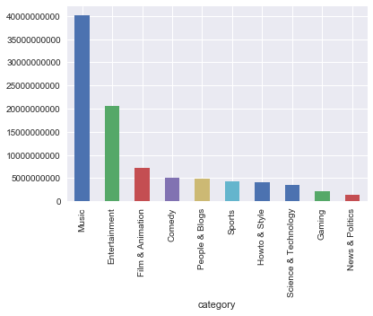

```python
df.groupby("category").views.sum().nlargest(10).plot.bar()
plt.gca().get_yaxis().get_major_formatter().set_scientific(False)
plt.show()
```

There are other ways to group our data as well. We can group by time, for example.

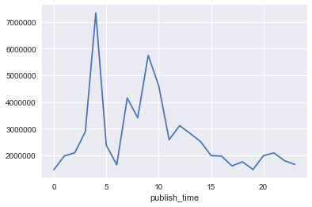

```python
time_grouper = pd.DatetimeIndex(df.publish_time)

best_post_times = df.groupby(time_grouper.hour)
best_post_times.views.mean().plot()

plt.gca().get_yaxis().get_major_formatter().set_scientific(False)
plt.show()
```

Why might the most successful videos be posted so early in the morning?

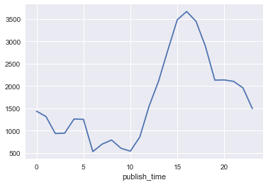

```python
best_post_times.video_id.count().plot()

plt.gca().get_yaxis().get_major_formatter().set_scientific(False)
plt.show()
```

## Brief Introduction to Natural Language Processing

##### (with a bit of deep learning)

"Tokenizing" means splitting our text into individual words, sentences, phrases, or even just letters - all referred to as "tokens."

```python
from big_data_scripts.nlp import *

tokenized = tokenize(df['title'])
tokenized.to_frame().head()
```

|  | title |
| --- | --- |
| 0 | [we, want, to, talk, about, our, marriage] |
| 1 | [the, trump, presidency, last, week, tonight, ... |
| 2 | [racist, superman, rudy, mancuso, king, bach, ... |
| 3 | [nickelback, lyrics, real, or, fake] |
| 4 | [i, dare, you, going, bald] |

$n-$grams $(\mathtt{context, target})$ pairs of words, where the size of $\mathtt{context}$ is equal to $n$.

For example, `(("yer", "a"), "wizard")` represents that the word "wizard" is preceeded by the two context words "yer" and "a". As there are $3$ words in question, we call this a *trigram* - if there were $2$, we'd call it a bigram, a unigram for $1$, and so on.

Even simply looking at trigram frequency can give a great look at what people are watching!

```python
from collections import Counter

trigrams = make_trigrams(tokenized)

gram_df = pd.DataFrame(Counter(trigrams).most_common(10), columns=["trigram", "count"])
gram_df.style.bar()
```

|  | trigram | count |
| --- | --- | --- |
| 0 | (('official', 'music'), 'video') | 441 |
| 1 | (('official', 'trailer'), 'hd') | 422 |
| 2 | (('how', 'to'), 'make') | 281 |
| 3 | (('the', 'last'), 'jedi') | 201 |
| 4 | (('official', 'video'), 'ft') | 179 |
| 5 | (('official', 'lyric'), 'video') | 154 |
| 6 | (('avengers', 'infinity'), 'war') | 147 |
| 7 | (('official', 'teaser'), 'trailer') | 142 |
| 8 | (('trailer', 'hd'), 'netflix') | 135 |
| 9 | (('star', 'wars'), 'the') | 135 |

## Neural Networks and Deep Learning - A Practical Example

After tokenizing our text data, we need to represent it in a way a computer can understand. To do this, we assign each token (in our case, each word) a unique number.

```python
from big_data_scripts.neural_network import *
from big_data_scripts.vocab import *

vocab = Vocab()
tokenized.apply(vocab.addList)

list(vocab.word2index.items())[:5]
```

```
[('we', 3), ('want', 4), ('to', 5), ('talk', 6), ('about', 7)]
```

From here, we can feed these numbers (in trigram form) into a "neural network," which you may have heard about.

*Note: Here, you see the network trained once on 25 examples. In reality, I trained it on about 92,000 examples for 6 loops, and it still wasn't very good! That's why the big companies spend so much computing power on this stuff.*

```python
FancyNN = YoutubeNeuralNetwork(vocab)
FancyNN.train(EPOCHS=1, BATCH_SIZE=25)
```

```
2019-03-12 22:33:12.295 | INFO     | big_data_scripts.neural_network:train:52 - Begin training
```

```
2019-03-12 22:33:12.635 | INFO     | big_data_scripts.neural_network:train:85 - Epoch 1/1: 9.325165786743163
2019-03-12 22:33:12.637 | INFO     | big_data_scripts.neural_network:save_progress:91 - Saving model checkpoint to file: YT_NN_EP1_TEP1_BS25.torch
```

```
[9.325165786743163]
```

Loading the saved model, we can take a glimpse at our data. This is our numeric representation of the word "youtube."

```python
model = torch.load("YT_NN_FINAL.torch")

print(model['youtube'].shape)
model['youtube']
```

```
torch.Size([1, 200])
```

```
tensor([[-1.9406, -0.0120, -0.3133,  0.0053,  0.5015, -1.5472,  2.1686, -0.4759,
         -0.4145,  0.3926,  2.1765, -0.8619, -0.4588, -0.1544,  0.2805, -1.6433,
         -0.6072,  0.3850,  2.7858, -0.8609, -1.9652, -0.4307,  0.7734, -0.0118,
          0.4662,  0.7570, -0.1216, -2.5097, -0.4403,  0.7610, -0.2263, -0.5579,
          0.8442,  1.8795,  1.3703, -0.1387, -1.2866, -1.2277,  0.9556,  0.1192,
         -1.0888,  2.7796,  1.2900,  1.0276, -1.1250,  3.8281,  0.8798, -0.7008,
          0.5990, -1.5850, -0.0440,  0.2456,  1.6168,  1.2200, -1.9468,  0.6593,
          1.1960,  0.4593, -0.6702, -1.8451,  2.2054,  1.5364, -1.5712,  1.7310,
          1.8256, -0.1310, -0.4584, -0.7093,  0.1162,  1.6298,  0.1817, -0.1406,
         -0.3664,  1.0069, -2.2419,  0.2265, -0.6465, -0.7956, -0.1883, -0.7869,
         -0.7542,  1.1626,  1.1267, -0.0078,  1.9863, -3.0799, -0.2717, -2.1401,
          0.5000,  0.1797,  0.5621, -0.5052, -1.0213, -1.1396,  0.3706,  0.2873,
         -1.0374, -1.0707,  1.6861,  1.1170, -0.0438, -0.5695,  0.4232, -0.1756,
          0.5864, -0.5788, -0.5489, -0.9428, -1.1567, -0.8392,  0.2723, -0.6071,
         -0.6823,  0.9999, -0.0997,  0.2406,  0.8948, -0.6845, -1.7521, -0.0114,
         -1.5581, -0.6389,  0.3049, -1.2423, -0.6244, -1.1311,  0.8315,  1.6257,
         -0.6005,  0.3280,  0.7026,  0.5396, -1.3772,  0.9477,  0.3131,  1.5963,
          0.4464,  0.3037,  0.1809,  1.0227, -0.1442, -0.7252,  0.0517, -0.8854,
          1.0309, -0.4741, -0.0853,  1.4625, -0.2310, -1.0477, -2.0578, -0.9728,
          1.0158, -2.5560,  0.4762,  0.3727,  0.3899,  0.2529, -0.3575,  0.7579,
         -0.6964, -0.1466, -1.3390, -1.7652,  0.9323,  1.1681, -0.0687, -1.1306,
         -0.0848,  0.5598,  0.3072,  0.7480, -0.1291, -1.7567, -0.5913,  1.0419,
         -0.3902,  0.5930, -0.0215,  0.2398, -0.2237,  0.6250,  1.2858, -0.5799,
         -1.2265, -0.0914, -0.2178,  1.3319, -0.4002, -0.0620,  0.4640, -0.0443,
          0.3477, -0.1807, -0.3323,  1.0229,  2.6406,  0.2830,  0.1710, -1.7539]],
       grad_fn=<IndexBackward>)
```

This lets us do all sorts of cool things! For example, we can predict the next word in a title, given the first two.

```python
next_word(["official", "music"], model)
```

```
official music =>
-----
video
nbc
awards
react
volcano
```

But maybe that was too easy. How about this example?

```python
next_word(["star", "wars"], model)
```

```
star wars =>
-----
show
story
cast
episode
jedi
```

Finally, if these representations are based on similarity, then we should be able to graph them. However, we can't visualize $200$ dimensions. We can use the `t-SNE` algorithm to *reduce the dimensionality*, also known as **dimensionality reduction**, to $3$-d, which we can then visualize.

```python
from big_data_scripts.plot_vectors import *
output = word_viz(model)
```

[interactive chart not shown]